# 111208094_hw1

1. 請讀入資料：stock = read_csv(“stock.csv”) 資料為2023/12/1~2024/3/7，5個股票的股價，變數為：id_name：每檔股票的證券代碼與名稱，如：2330台積電，表示證券代碼2330，公司名稱為台積電。type：open 代表開盤價，close 代表收盤價。 2023/12/1：為該天交易價格（剩下日期變數依此類推）。 請用tidyr提到的gather,spread,sperate等函數指令，將資料整理成下方「tidy」格式

```r
#By myself (我寫好爛好長)
install.packages("readr")
library(readr)
library(tidyr)
stock_short <- read_csv("C:\\Users\\Ava\\Desktop\\R\\HW1\\stock.csv")
stock_short1 <-separate(stock_short,id_name,into = c("id","name"),sep = " ")
stock_short2 <- gather(stock_short1,key = "time" ,value = "value", -id,-name,-type)
stock_short3 <-separate(stock_short2,time,into = c("year","month","date"),sep = "/")
stock_long <- pivot_wider(stock_short3, names_from = type, values_from = value)
print(stock_long) #answer
```

```
## # A tibble: 305 × 7
##    id    name   year  month date    open  close
##    <chr> <chr>  <chr> <chr> <chr>  <dbl>  <dbl>
##  1 2330  台積電 2024  3     7      755    760
##  2 2002  中鋼   2024  3     7       24     24.0
##  3 2885  元大金 2024  3     7       27.3   28.1
##  4 9904  寶成   2024  3     7       30.3   30.4
##  5 2454  聯發科 2024  3     7     1220   1230
##  6 2330  台積電 2024  3     6      718    735
##  7 2002  中鋼   2024  3     6       24.0   24.0
##  8 2885  元大金 2024  3     6       27.4   27.5
##  9 9904  寶成   2024  3     6       30.5   30.3
## 10 2454  聯發科 2024  3     6     1145   1190
## # ℹ 295 more rows
```

2. 電商公司，有三個資料集合：

sales.df：產品銷售狀況 （“salesID”銷售紀錄編號，“Store”店家編號， “Product”產品編號，“Client”顧客編號，“UnitPrice”單價，“Quantity”購買數量，“Region”顧客國家 ）

client.df：顧客的個人資料 (“Client”顧客編號，“Age”年紀，“Membership”會員等級， “Gender”性別 )

prod.df：產品的相關資料（“Item” 代號＿產品） 請用tidyverse套件裡學到的方法，分析

(1.) prod.df 裡將兩個變數，誤紀錄為在同一個column，其將其分開為兩個變數Product（數字部分）及Item（商品部分），取代原prod.df。 (2.) 將3個報表合併為full.table (3.) 在full.table. 新增一個變數「總消費」為spend = UnitPrice*Quantity (4.) 在full.table將會員等級分組，其中gold和diamond的顧客為一組，其他等級的為一組，針對兩組客戶進行比較介紹（例如平均年紀、性別、國家、消費情況差異等）。 (5.) 在full.table針對女性客戶進行分析（例如平均年紀、國家、消費情況等），並對他們在不同產品的「總消費」畫圖分析。

```r
#資料匯入
client_list <- read_csv("C:\\Users\\Ava\\Desktop\\R\\HW1\\client_list.csv")
```

[output not shown]

```r
salesdata <- read_csv("C:\\Users\\Ava\\Desktop\\R\\HW1\\salesdata.csv")
```

[output not shown]

```r
product_list <- read_csv("C:\\Users\\Ava\\Desktop\\R\\HW1\\product_list.csv")
#(1.)
product_list1 <- separate(product_list,Item,into = c("Product","Item"),sep = "_",,convert=TRUE)
product_list1
```

```
## # A tibble: 6 × 2
##   Product Item
##     <int> <chr>
## 1     101 iPhone
## 2     102 iPad
## 3     103 MacBook
## 4     104 iMac
## 5     105 AirPods
## 6     106 AppleWatch
```

[output not shown]

```r
#(3.)
full_table%>%
  mutate( Spend = UnitPrice*Quantity ) -> full_table1
library(writexl)
write_xlsx(full_table1, path = "C:/Users/Ava/Downloads/full_table1.xlsx") #保存下來方便之後跑EDA!!
full_table1
```

```
## # A tibble: 100 × 13
##    ...1.x Store Product Client UnitPrice Quantity Region   ...1.y   Age
##     <dbl> <chr>   <dbl>  <dbl>     <dbl>    <dbl> <chr>     <dbl> <dbl>
##  1      1 A         103      1        10       72 Brazil        1    36
##  2     25 A         103      1        18       26 Korea         1    36
##  3     28 C         105      1        11        4 Japan         1    36
##  4     10 A         103      2        14       58 China         2    46
##  5     11 C         101      2         8       35 Brazil        2    46
##  6     41 B         105      2         4       76 Korea         2    46
##  7     59 B         101      2         7       58 Korea         2    46
##  8     67 B         105      2        14       98 Thailand      2    46
##  9     84 C         105      2        14       59 Germany       2    46
## 10     97 B         105      2         9       20 Brazil        2    46
## # ℹ 90 more rows
## # ℹ 4 more variables: Membership <chr>, Gender <chr>, Item <chr>, Spend <dbl>
```

```r
#(4.) EDA Start!!!
#分組
full_table2 <- full_table1 %>%
  mutate(Group = ifelse(Membership %in% c("gold", "diamond"), "Gold & Diamond", "Other"))
full_table2
```

```
## # A tibble: 100 × 14
##    ...1.x Store Product Client UnitPrice Quantity Region   ...1.y   Age
##     <dbl> <chr>   <dbl>  <dbl>     <dbl>    <dbl> <chr>     <dbl> <dbl>
##  1      1 A         103      1        10       72 Brazil        1    36
##  2     25 A         103      1        18       26 Korea         1    36
##  3     28 C         105      1        11        4 Japan         1    36
##  4     10 A         103      2        14       58 China         2    46
##  5     11 C         101      2         8       35 Brazil        2    46
##  6     41 B         105      2         4       76 Korea         2    46
##  7     59 B         101      2         7       58 Korea         2    46
##  8     67 B         105      2        14       98 Thailand      2    46
##  9     84 C         105      2        14       59 Germany       2    46
## 10     97 B         105      2         9       20 Brazil        2    46
## # ℹ 90 more rows
## # ℹ 5 more variables: Membership <chr>, Gender <chr>, Item <chr>, Spend <dbl>,
## #   Group <chr>
```

```r
#年紀
age_comparison <- full_table2 %>%
  group_by(Group) %>%
  summarise(Average_Age = mean(Age, na.rm = TRUE))
age_comparison
```

```
## # A tibble: 2 × 2
##   Group          Average_Age
##   <chr>                <dbl>
## 1 Gold & Diamond        41.8
## 2 Other                 40.9
```

```r
#性別
gender_comparison <- full_table2 %>%
  group_by(Group, Gender) %>%
  summarise(Count = n()) %>%
  mutate(Percentage = Count / sum(Count) * 100)
gender_comparison
```

```
## # A tibble: 4 × 4
## # Groups:   Group [2]
##   Group          Gender Count Percentage
##   <chr>          <chr>  <int>      <dbl>
## 1 Gold & Diamond female    43       75.4
## 2 Gold & Diamond male      14       24.6
## 3 Other          female    21       48.8
## 4 Other          male      22       51.2
```

```r
#國家
country_comparison <- full_table2 %>%
  group_by(Group, Region) %>%
  summarise(Count = n()) %>%
  arrange(Group, desc(Count))
country_comparison
```

```
## # A tibble: 20 × 3
## # Groups:   Group [2]
##    Group          Region   Count
##    <chr>          <chr>    <int>
##  1 Gold & Diamond China        8
##  2 Gold & Diamond Korea        8
##  3 Gold & Diamond Germany      6
##  4 Gold & Diamond Taiwan       6
##  5 Gold & Diamond Thailand     6
##  6 Gold & Diamond Brazil       5
##  7 Gold & Diamond France       5
##  8 Gold & Diamond Spain        5
##  9 Gold & Diamond USA          5
## 10 Gold & Diamond Japan        3
## 11 Other          Korea       11
## 12 Other          Taiwan       6
## 13 Other          Spain        5
## 14 Other          USA          5
## 15 Other          Brazil       4
## 16 Other          France       4
## 17 Other          China        3
## 18 Other          Germany      2
## 19 Other          Thailand     2
## 20 Other          Japan        1
```

```r
#消費差異
spend_comparison <- full_table2 %>%
  group_by(Group) %>%
  summarise(Average_Spend = mean(Spend, na.rm = TRUE),
            Total_Spend = sum(Spend, na.rm = TRUE),
            Std_Dev_Spend = sd(Spend, na.rm = TRUE))
```

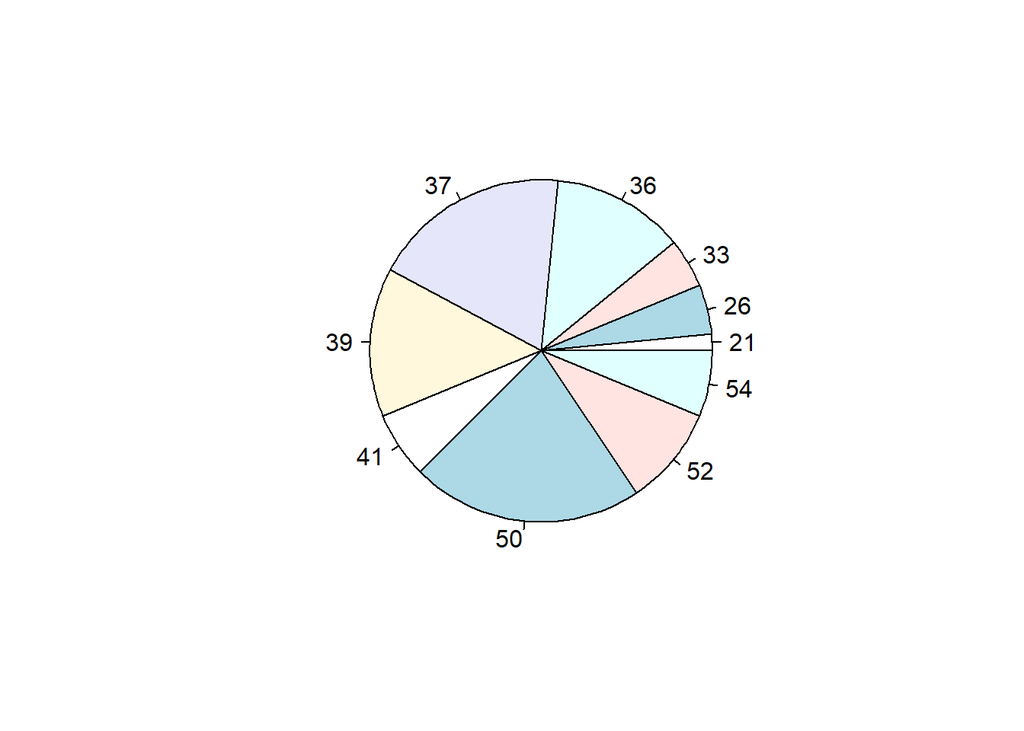

```r
#(5.)
full_table2_female <- full_table2[full_table2$Gender =="female",]
write_xlsx(full_table2_female, path = "C:/Users/Ava/Downloads/full_table2_female.xlsx")

#年紀
age_comparison_female <- full_table2_female %>%
  summarise(Average_Age = mean(Age, na.rm = TRUE))

pie(table(full_table2_female$Age))
```

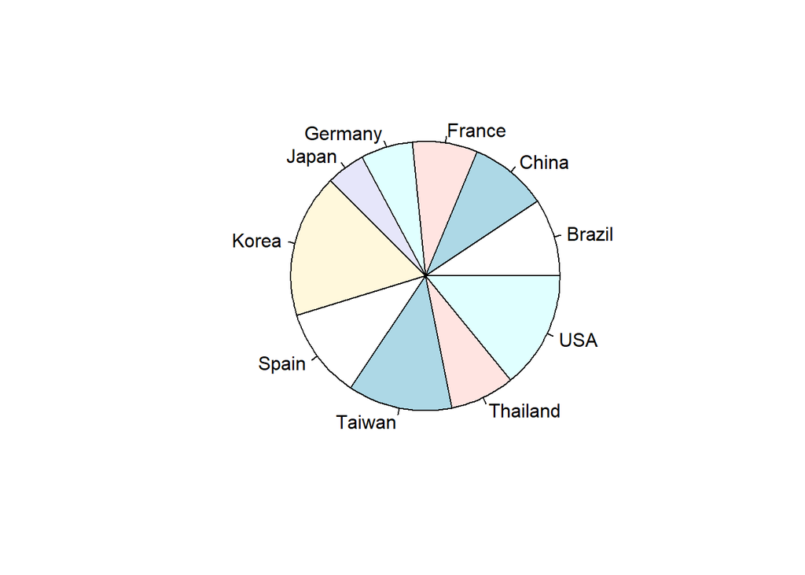

```r
#國家
country_comparison_female <- full_table2_female %>%
  group_by(Region) %>%
  summarise(Count = n()) %>%
  arrange(desc(Count))

pie(table(full_table2_female$Region))
```

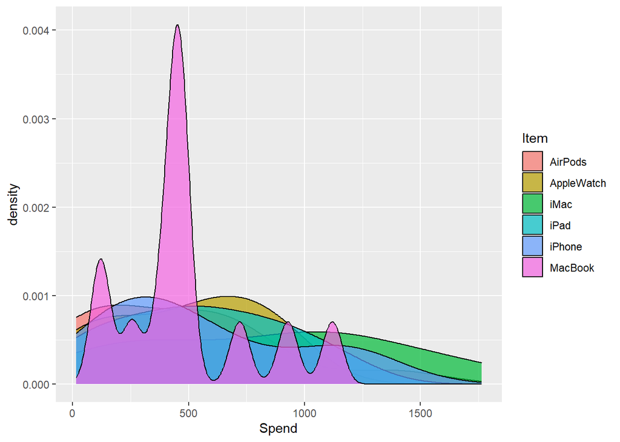

```r
#消費差異
spend_comparison_female <- full_table2_female %>%
  summarise(Average_Spend = mean(Spend, na.rm = TRUE),
            Total_Spend = sum(Spend, na.rm = TRUE),
            Std_Dev_Spend = sd(Spend, na.rm = TRUE))

#不同產品的「總消費」畫圖分析
library(ggplot2)
p <- ggplot(full_table2_female, aes(x = Spend , fill = Item)) + geom_density(alpha = 0.7)
plot(p, labels = "AUTO")
```

```r
plot
```

[output not shown]